# Model Builder

Author

James

## Imports

```python
import pandas as pd
import numpy as np
import importlib
from joblib import dump, load
from datetime import datetime as dt
from sklearn.metrics import mean_squared_error, mean_absolute_error
from sklearn.model_selection import train_test_split
from transformers import BertTokenizer, TFBertModel
import tensorflow as tf
from tensorflow.keras.preprocessing.text import Tokenizer
from tensorflow.keras.preprocessing.sequence import pad_sequences
from tensorflow.keras.models import Sequential
from tensorflow.keras.layers import Embedding, LSTM, Dense, Dropout
from tensorflow.keras.models import Model
```

## Data Loading

I will use the FOMC speeches and compare how they affect the S&P500 Index.

```python
speechesDF = pd.read_csv("data/speechData.csv").iloc[:,1:] #Removes extra col

speechesDF.columns
speeches = speechesDF.groupby(['Title', 'Name', 'Date', 'Length'])['Text'].apply(list).reset_index()
snpDF = pd.read_csv("data/stocks/snp.csv").iloc[:,1:]
```

## Data Manipulation

I want to see the lasting effects from a speech. I will use the 5 day percent change for this. How much did the index change over the five days *after* the speech?

```python
snpDF["5day%Change"] = [(snpDF["snp_Close"][i + 5] - snpDF["snp_Close"][i]) / snpDF["snp_Close"][i] for i in range(len(snpDF["snp_Close"]) - 5)] + [0 for _ in range(5)]
```

Now, let’s make sure we only consider the days that have both a speech and stock data.

```python
snp_using = snpDF[snpDF["Date"].isin(speechesDF["Date"])]
fomc_using = speechesDF[speechesDF["Date"].isin(snpDF["Date"])].drop_duplicates(subset=['Date']) #Removing multiple speeches on the same day for now
assert(len(fomc_using) == len(snp_using))

speeches = fomc_using["Text"][:-5]
labels = snp_using["5day%Change"][:-5] #Last 5 are 0's
```

# Individual Model Creating

## Preprocessing

```python
# Parameters
max_vocab_size = 5000 # Limit on most common unique words
max_sequence_length = 100 # Limit on sentence length
embedding_dim = 128 # Word vector dimension

# Tokenization
tokenizer = Tokenizer(num_words=max_vocab_size)
tokenizer.fit_on_texts(speeches) # Creates a token for each word
sequences = tokenizer.texts_to_sequences(speeches)
padded_sequences = pad_sequences(sequences, maxlen=max_sequence_length, padding='post') #Push sequences to a fixed length

X_train, X_test, y_train, y_test = train_test_split(padded_sequences, labels, test_size = 0.3, random_state = 10)
```

## Model Creation

```python
def lstmModel():
    '''
    Method to create a Deep Learning Recurrent Neural Network
    '''
    model = Sequential([
        Embedding(input_dim=max_vocab_size, output_dim=embedding_dim),
        LSTM(128, return_sequences=True),
        Dropout(0.5), #prevent overfitting
        LSTM(64),
        Dropout(0.5),
        Dense(1)  # Regression output
    ])
    return model

# Creating two models: One with MSE and one with MAE as the error term
MSElstm = lstmModel()
MAElstm = lstmModel()

MSElstm.compile(optimizer='adam', loss='mean_squared_error', metrics=['mean_absolute_error'])
MAElstm.compile(optimizer='adam', loss='mean_absolute_error', metrics=['mean_absolute_error'])

MSElstm.fit(X_train, y_train, epochs=10, batch_size=32)
MAElstm.fit(X_train, y_train, epochs=10, batch_size=32)

dump(MSElstm, "models/speeches/MSElstm.joblib")
dump(MAElstm, "models/speeches/MAElstm.joblib")
```

```python
MSElstm = load("models/speeches/MSElstm.joblib")
MAElstm = load("models/speeches/MAElstm.joblib")
```

## Analysis

```python
mse = [mean_squared_error(MSElstm.predict(X_test), y_test), mean_squared_error(MAElstm.predict(X_test), y_test)]
mae = [mean_absolute_error(MSElstm.predict(X_test), y_test), mean_absolute_error(MAElstm.predict(X_test), y_test)]

# Comparing the models against each other
pd.DataFrame({
  "Model" : ["MSE", "MAE"],
  "MSE" : mse,
  "MAE" : mae
})
```

```
1/5 ━━━━━━━━━━━━━━━━━━━━ 1s 308ms/step3/5 ━━━━━━━━━━━━━━━━━━━━ 0s 28ms/step 5/5 ━━━━━━━━━━━━━━━━━━━━ 0s 82ms/step5/5 ━━━━━━━━━━━━━━━━━━━━ 1s 82ms/step
1/5 ━━━━━━━━━━━━━━━━━━━━ 1s 268ms/step3/5 ━━━━━━━━━━━━━━━━━━━━ 0s 29ms/step 5/5 ━━━━━━━━━━━━━━━━━━━━ 0s 83ms/step5/5 ━━━━━━━━━━━━━━━━━━━━ 1s 83ms/step
1/5 ━━━━━━━━━━━━━━━━━━━━ 0s 46ms/step3/5 ━━━━━━━━━━━━━━━━━━━━ 0s 28ms/step5/5 ━━━━━━━━━━━━━━━━━━━━ 0s 26ms/step
1/5 ━━━━━━━━━━━━━━━━━━━━ 0s 42ms/step3/5 ━━━━━━━━━━━━━━━━━━━━ 0s 27ms/step5/5 ━━━━━━━━━━━━━━━━━━━━ 0s 25ms/step
```

|  | Model | MSE | MAE |
| --- | --- | --- | --- |
| 0 | MSE | 0.000513 | 0.016602 |
| 1 | MAE | 0.000504 | 0.015571 |

At a glance, this appears to handle the data quite well! Let’s consider the plot of the actual change versus the predicted change.

## Visualization

```python
import matplotlib.pyplot as plt
from matplotlib.ticker import MultipleLocator
import matplotlib.patches as mpatches
import seaborn as sns
```

```
1/5 ━━━━━━━━━━━━━━━━━━━━ 0s 49ms/step3/5 ━━━━━━━━━━━━━━━━━━━━ 0s 31ms/step5/5 ━━━━━━━━━━━━━━━━━━━━ 0s 27ms/step
1/5 ━━━━━━━━━━━━━━━━━━━━ 0s 49ms/step3/5 ━━━━━━━━━━━━━━━━━━━━ 0s 30ms/step5/5 ━━━━━━━━━━━━━━━━━━━━ 0s 26ms/step
```

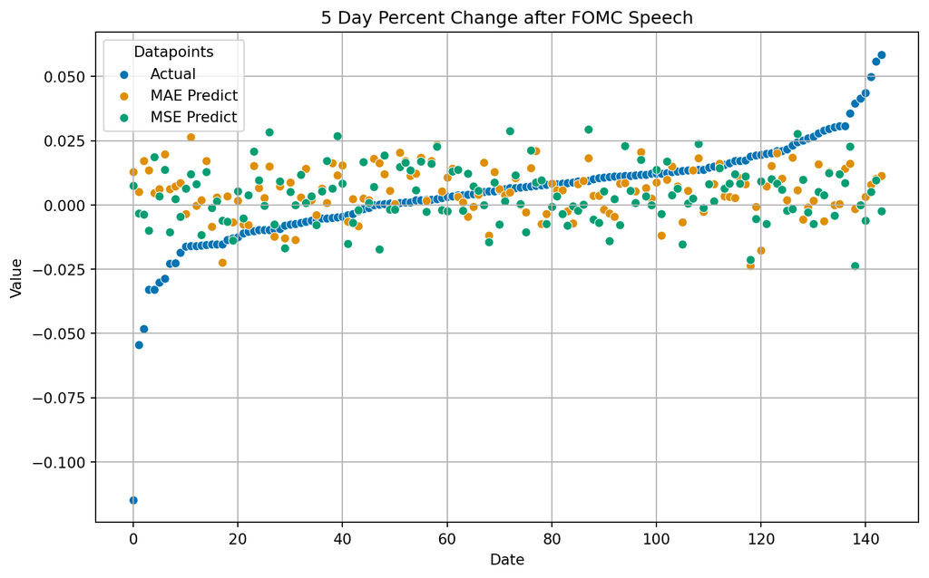

```python
df = pd.DataFrame({
  "Actual" : list(y_test),
  "MAE Predict" : [i[0] for i in list(MAElstm.predict(X_test))],
  "MSE Predict" : [i[0] for i in list(MSElstm.predict(X_test))]
}).sort_values(by='Actual').reset_index().drop(columns=["index"])

colors = sns.color_palette("colorblind")

# Plotting
plt.figure(figsize=(10, 6))
for i, column in enumerate(df.columns):
    sns.scatterplot(x=df.index, y=df[column], label=column, color=colors[i])

plt.title('5 Day Percent Change after FOMC Speech')
plt.xlabel('Date')
plt.ylabel('Value')
plt.legend(title='Datapoints')
plt.grid(True)
plt.show()
```

```
1/5 ━━━━━━━━━━━━━━━━━━━━ 0s 50ms/step3/5 ━━━━━━━━━━━━━━━━━━━━ 0s 30ms/step5/5 ━━━━━━━━━━━━━━━━━━━━ 0s 28ms/step5/5 ━━━━━━━━━━━━━━━━━━━━ 0s 28ms/step
```

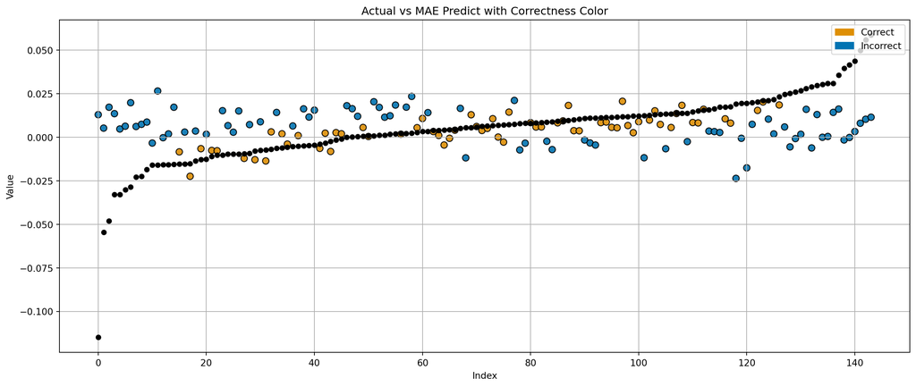

```python
df = pd.DataFrame({
    "Actual": list(y_test),
    "MAE Predict": [i[0] for i in list(MAElstm.predict(X_test))]
}).sort_values(by='Actual').reset_index().drop(columns=["index"])
df['Correctness'] = abs(df["Actual"] - df["MAE Predict"]) < 0.01

plt.clf()

df = df.reset_index()
fig, ax = plt.subplots(figsize=(14, 6))

# Define the color palette and map colors based on 'Correctness'
palette = sns.color_palette("colorblind", 2)
df['Color'] = df['Correctness'].map({True: palette[1], False: palette[0]})

# Actual scatterplot
ax.plot(df.index, df['Actual'], 'ko', label='Actual', markersize=5)  # 'ko' is dark color and circle markets

# Predict scatterplot
scatter = plt.scatter(x=df['index'], y=df['MAE Predict'], c=df['Color'], s=50, alpha=0.9, edgecolor='k')

# Manaually create legend to fix matplotlib issue
correct_patch = mpatches.Patch(color=palette[1], label='Correct')
incorrect_patch = mpatches.Patch(color=palette[0], label='Incorrect')

# Plot legend
plt.legend(handles=[correct_patch, incorrect_patch], loc='upper right')

# Axis labels
plt.grid(True)
plt.xlabel('Index')
plt.ylabel('Value')
plt.title('Actual vs MAE Predict with Correctness Color')

plt.tight_layout()
plt.show()
```

We can do the same process to see the results for the mean squared error model.

```
1/5 ━━━━━━━━━━━━━━━━━━━━ 0s 58ms/step3/5 ━━━━━━━━━━━━━━━━━━━━ 0s 30ms/step5/5 ━━━━━━━━━━━━━━━━━━━━ 0s 26ms/step
```

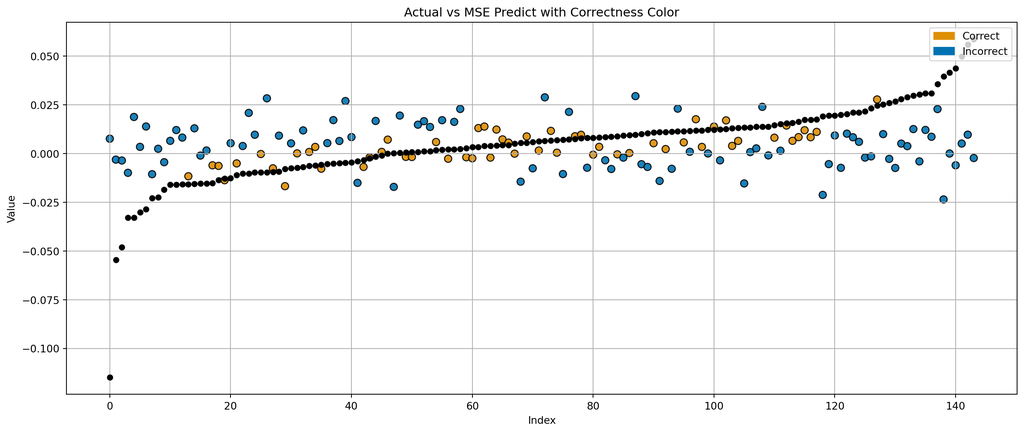

```python
df2 = pd.DataFrame({
    "Actual": list(y_test),
    "MSE Predict": [i[0] for i in list(MSElstm.predict(X_test))]
}).sort_values(by='Actual').reset_index().drop(columns=["index"])
df2['Correctness'] = abs(df["Actual"] - df2["MSE Predict"]) < 0.01

plt.clf()

df2 = df2.reset_index()
fig, ax = plt.subplots(figsize=(14, 6))

# Define the color palette and map colors based on 'Correctness'
palette = sns.color_palette("colorblind", 2)
df2['Color'] = df2['Correctness'].map({True: palette[1], False: palette[0]})

# Actual scatterplot
ax.plot(df2.index, df2['Actual'], 'ko', label='Actual', markersize=5)  # 'ko' is dark color and circle markets

# Predict scatterplot
scatter = plt.scatter(x=df2['index'], y=df2['MSE Predict'], c=df2['Color'], s=50, alpha=0.9, edgecolor='k')

# Manaually create legend to fix matplotlib issue
correct_patch = mpatches.Patch(color=palette[1], label='Correct')
incorrect_patch = mpatches.Patch(color=palette[0], label='Incorrect')

# Plot legend
plt.legend(handles=[correct_patch, incorrect_patch], loc='upper right')

# Axis labels
plt.grid(True)
plt.xlabel('Index')
plt.ylabel('Value')
plt.title('Actual vs MSE Predict with Correctness Color')

plt.tight_layout()
plt.show()
```

```python
print(f'MAE got {len([i for i in range(len(df)) if list(df["Correctness"])[i]]) * 100 / len(df)}% correct while MSE got {np.round(len([i for i in range(len(df)) if list(df2["Correctness"])[i]])* 100 / len(df), 2)}% correct')
```

```
MAE got 45.138888888888886% correct while MSE got 38.89% correct
```